# 5 Spam Classifier – Data Science at SAMY

## 5.1 Introduction

In the Peaks and Pits, and Conversation Landscape case studies, we walked through some of our fundamental project offerings. Here we walk through a different type of project, where the goal of the research was twofold:

1. To produce thought leadership-style guidance for preserving the quality of data on social.
2. To create a model, or a set of models & heuristics, to identify high-quality data on social.

This document covers 2. The deck we presented to the client can be found [here](https://sharecreate-my.sharepoint.com/:p:/g/personal/jack_penzer_sharecreate_onmicrosoft_com/EerD104EWE1In2t2iimhrFEBXRDb34NgXmmpSoJhMH9Vvg?rtime=hIvTAPn_3Eg)

## 5.2 Spam Classifier

The vast majority of our work is centred around answering research questions which are proscribed to us by stakeholders. To achieve this aim, we try to extract, understand, and represent the organic opinions of real people. Our work is good in proportion to how accurately we can do this: the more organic & accurate data that we extract, the better our answers, and vice versa.

As practitioners we have all lived through the frustration of arriving at the end of a research project only to find an overlooked cluster of spam is skewing our results; sending us back to the beginning of the process to clean the data and repeat the analysis. When this happens it can be draining on both time and motivation, and if we’re pressed for either than we may end up producing work that isn’t accurate, or isn’t as accurate as it could be.

## 5.3 Motivation

Take the following sentiment distribution:

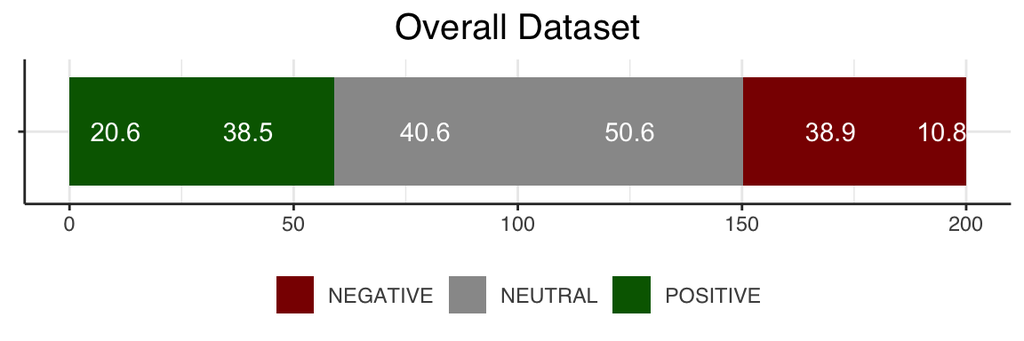

Figure 1. Sentiment Distribution

The chart indicates an approximately even split between Positive and Negative, and a large proportion of Neutral. This distribution is common and unremarkable. We could make some reasonable inferences about the data based on this distribution. However, lurking under the surface is a problem similar to [Simpson’s Paradox](https://en.wikipedia.org/wiki/Simpson%27s_paradox).

For example, if we separate our dataset into groups of ‘Spam’ and ‘Not Spam’, the balance between Positive and Negative disappears entirely. The ‘Spam’ section of the dataset has ~4x as many Positive mentions than Negative, whereas the ‘Not Spam’ section has ~2x as many Negative than Positive; an ~8x swing.

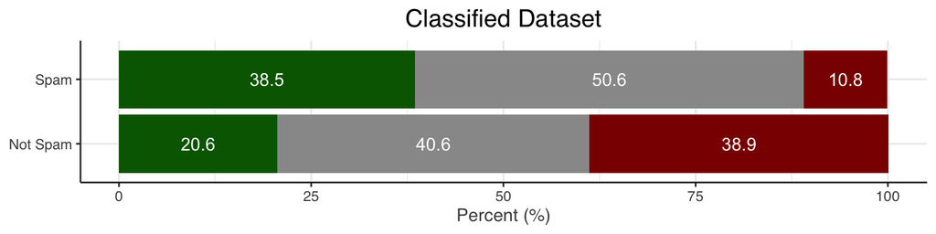

Figure 1.1. Removing ‘Spam’ has a dramatic effect on the distribution of sentiment in a dataset.

Practically speaking, failure to remove spam could be the difference between deriving an accurate picture of reality and not, or, a correctly-timed strategic intervention and continuing as-is, assuming everything is ok.

We also want to:

1. Reduce time spent cleaning data
2. Increase consistency of output
3. Try our best to comply with the assumptions of the algorithms we use, e.g. for clustering or topic modelling

## 5.4 What is Spam?

Broadly speaking, we can define spam as **‘Unwanted, irrelevant, or unsolicited mentions sent to large audiences.’** However, whether something is unwanted or irrelevant is open to interpretation and varies with context; so precisely stating what each of these words means is difficult. Despite this difficulty, we will mostly tend to agree with one another when we actually see spam. There is a certain ‘know it when I see it’ aspect of spam.

It should be quite clear which of the following two documents is spam and which is not:

> “Need help with online exams, assignments, research projects, or dissertations? Look no further! I can assist with proofreading, personal statements, and more. Let’s tackle #MachineLearning, #DataScience, #Python, #Cybersecurity, #BigData, #AI, #IoT, #DeepLearning, #NLP together!”

> “I think one of the big open questions is whether anyone will challenge the order in court. It uses presidential emergency powers to require red-teaming of foundation models. Initially that may only affect companies like OpenAI and Anthropic that have been asking for regulation.”

## 5.5 Methodology

With our loose definition of ‘Spam’ in place, we used its ‘know it when I see it’ property to curate a corpus of ‘Spam’ and ‘Not Spam’ mentions. We then used a Transfer Learning[^1] approach to fine-tune a foundational Language Model to classify data into ‘Spam’ and ‘Not Spam’.

When labelling ‘Spam’ and ‘Not Spam’ we added optional labels as the need arose. For example, we saw a lot of spam regarding wallet scams, memecoins, crypto price updates, sustainabile coins, and a whole lot more relating to cryptocurrencies, so we added a label for ‘Crypto’.

**Creating Labels on the Fly**

In a project like this, creating new labels as we went was inevitable, because we were discovering/learning about the nature of Spam as we labelled, and as part of the research brief we were to create a taxonomy of spam - meaning we needed to identify groups of spam from the data.

That said, if we introduce a new label at data point 1,000, are we *really* going to go back and check which of the previous 1,000 data points may fit into that label? The answer is most likely no. **Depending on what you’re using these labels for, this may or may not be harmful.** For our cases, the additional labels were of secondary importance, so we could tolerate them not being consistent throughout the dataset. We also set out to identify cases off LLM-generated slop [^2]

To be clear, the important label for the model was ‘Spam’ vs ‘Not Spam’.

Visit the Data Labelling Strategy document for more information on strategies for curating datasets.

Creating the additional labels served two main purposes:

1. Priors for a Taxonomy of Spam
2. Discrete variables to systematically improve model performance

We were delivering the Taxonomy as a scoped commitment, and we will talk about 2. in more detail in the Systematically Improving a Model Section.

When selecting models to test we needed to consider the following constraints:

- Weights are open-source
- Permissive License
- Capable of performing the task at hand
- Can be fine-tuned on consumer hardware
- Simple to deploy and run inference at scale

## 5.6 Corpus

Each tab houses a selection of the texts which have been assigned that label inside the corpus, click through the tabs to start building a mental model for the type of data that will be removed by the classifier.

**Warning**

It is crucial when using the model that you understand what you are removing, and that you are happy that what you are removing is not indispensable for your research question(s). Never blindly remove data.

**Promotion**

Something worth detailing here is that in the early labels, before it was clear that people sharing their AI Generations might be their own type of spam, I was considering links to AI images as a form of promotion. If the goal was to separate promotions from AI generations this would be problematic.

However, this corpus is for separating ‘Spam’ from ‘Not Spam’, so we can accept some fuzziness between categories.

|  | spam_corpus_id | text | classification_label | split_name |
| --- | --- | --- | --- | --- |
| 1 | scid_1489 | New tag showoff featuring a wonderful kit by Starlite &amp; Soul called "You're a Mean One". You can purchase the kit at her store: Starlite &amp; Soul The kit contains a AI tube; however, I used a st… | promotion | promo |
| 2 | scid_1499 | ❤Beautiful Greek Mature Women❤ Mature women are wearing shapewear in colors never seen before in this world. This is a fictitious character by AI. Prompt is open to the public. patreon.com/posts/beaut… | promotion | promo |
| 3 | scid_1517 | BooksAI - Book summaries right from your camera. Category : #Summarizer Explore BooksAI AI Tool User Reviews, Tutorials, Pricing and Best Alternatives in 2023 beseen.academy/ai-tools/books… | promotion | promo |
| 4 | scid_1520 | Restore your most beautiful, look of nature with the help of upgraded AI Portrait Retouching of #OPPOA38 😍 Know more: https://www.oppo.com/np/smartphones/series-a/a38/ #ShotonOPPO #OPPONepal | promotion | promo |
| 5 | scid_1523 | Dive into the future of sound with our detailed review of Prestige Audio AI 🎧 Read more, and dare to believe your ears! 🔊: junaidmk.com/prestige-audio… #AudioTech #RevolutionInSound | promotion | promo |
| 6 | scid_1536 | AI Generated artwork pic.twitter.com/fsFD3LHzyY | image#promotion | promo |
| 7 | scid_1544 | Tired of boring logo art? Let AI rekindle your creative flame. Here are the 20 Best Ideogram AI Logo Prompts: ⤵️ Just Copy-Paste the Prompts, and see the magic. [Bookmark to try later] Prompt 1: Vecto… | promotion#slop | promo |
| 8 | scid_1580 | Anime AI Generated Intercity 125 HST FTW! pic.twitter.com/UrV1qYx0kf | promotion | promo |
| 9 | scid_1631 | AI has indeed revived many products, and now Walling AI has arrived. producthunt.com/posts/walling-… | article_link#promotion | promo |
| 10 | scid_1661 | Today we decided to add some spicy content of our beloved beauty @Glamazontyomi 😍 We were curious about AI tools of making our fantasies look real!😈 Hope you like it, she is inspiration and the bigges… | promotion | promo |

[output cut: 10 more lines]

**Slop**

It is not always possible to tell whether something was written by an AI, a person, or a person using AI. Some slop, however, is much more obvious than others.

|  | spam_corpus_id | text | classification_label | split_name |
| --- | --- | --- | --- | --- |
| 1 | scid_27 | There's buzz about a potential RAM slider feature coming soon. RAM is your computer's short-term memory, and browsers have a knack for devouring it. With this slider, you'll have the power to adjust h… | slop | slop |
| 2 | scid_70 | Learn how to create a LinkedIn Post using the best free AI social media post generator called FlyPost AI. FlyPost AI is embedded inside of the FlyMSG.io tool. 🤖📝 💡 Say goodbye to the hassle of composi… | slop | slop |
| 3 | scid_516 | 🚀 Are you really a Frontend Developer? Don’t claim the title unless you’re fluent in these essentials! 🛠️ ✅ 𝗛𝗧𝗠𝗟 &amp; 𝗖𝗦𝗦 𝗠𝗮𝘀𝘁𝗲𝗿𝘆: Understand the skeleton and skin of the web. Your HTML should be sem… | slop | slop |
| 4 | scid_731 | [EZ TIPS FOR TODAY] Unleash Your Productivity with Copilot in Edge! 💼🚀 Why sweat the small stuff when Copilot can lend a hand? In the realm of Microsoft Edge, Copilot is your trusty sidekick, ready to… | slop | slop |
| 5 | scid_1641 | @MaggsSmith1 Wow, that's some next-level AI talk! It's amazing how far we've come, right? 🚀 | slop | slop |
| 6 | scid_1847 | @CoinMarketCap Embark on a journey of technological allure with @matrixainetwork. 🚀 Precision, professionalism, and the power of blockchain and AI converge, reshaping decentralized intelligence. 🌐 Ele… | crypto#slop | slop |
| 7 | scid_1920 | @QuantopiaAi Thats amazing news! Microsoft is truly excelling in the AI race. Congrats to #Microsoft $MSFT $SPY! 🎉🚀 | slop | slop |
| 8 | scid_2058 | 🌐 MLOps is not just a trend, it's the future of machine learning in the production environment. Embrace it to transform your AI initiatives from experimental to operational. Share your thoughts and ex… | slop | slop |
| 9 | scid_2868 | Koperasi Inspira Jabodetabek Slide 1: 🌟 Welcome to Koperasi Inspira Jabodetabek! 🌐 Join us as we empower our community through cooperative initiatives, financial literacy, and sustainable growth. Let'… | slop | slop |
| 10 | scid_2926 | 6/6: Join us on the journey towards a more efficient, sustainable, and connected world. 🚀 Discover the possibilities with Karrier One today and be a part of the logistics revolution! #KarrierOne #Logi… | slop | slop |

[output cut: 10 more lines]

**Crypto**

|  | spam_corpus_id | text | classification_label | split_name |
| --- | --- | --- | --- | --- |
| 1 | scid_2887 | 🚀 Dive into $RYE and renewable energy investments! Join us on Telegram @Renewergy for updates on our REC marketplace. #RenewableEnergy 🔋🌐 | crypto | crypto |
| 2 | scid_5054 | Index Coop has embraced Chainlink's Cross-Chain Interoperability Protocol (CCIP), the industry's gold standard for secure cross-chain communication, across both Ethereum and Arbitrum mainnets. This in… | crypto#report | crypto |
| 3 | scid_832 | Witnessing the birth of a new art movement with @nfprompt's AI tool. Astonishingly easy and fun! 🎉👾 #NFTMovement #AIArt $NFP #NFPrompt nfprompt.io/profile/0x8D2d… | crypto | crypto |
| 4 | scid_5605 | EP20: We’re talking @Nilesecure Launches a Differentiated NaaS Offering, @NVIDIA GTC 2024, @Qualcomm On-device AI, @Microsoft Announces GA of its Copilot for Security, @Oracle Autonomous Database, AI … | announcement#crypto | crypto |
| 5 | scid_860 | Join me at @AINNLayer2 , the leading #AI-modular #Bitcoin #Layer2 solution. Sign up and earn points for free, sharing in the potential of future airdrops! Building on @AINN_BRC20, let's make BTC &amp;… | crypto | crypto |
| 6 | scid_3095 | @JakeGagain Turkey's trailblazing team launched Evadore in May 2023, pioneering a blockchain mission to combat climate change. 🇹🇷⛓️ Join us in leading the charge towards carbon neutrality by embracing… | crypto#slop | crypto |
| 7 | scid_5059 | The post appeared first on Coinpedia Fintech News Traders are turning bullish on Bitcoin again after it surged by a strong % in the past week, allowing it to reach the high of $,. The sudden price ris… | bad_scraping#crypto | crypto |
| 8 | scid_3708 | @cryptojack @Optimus_AI_BSC Optimus_AI_BSC is a powerful ECOSYSTEM which includes a suite of innovative features. 1️⃣TOKEN UTILITIES 2️⃣TADING UTILITIES 2️⃣AI UTILITIES ✅ KYC+SAFU+AUDIT #AI #OptimusAi… | crypto | crypto |
| 9 | scid_1310 | The world’s #1 source of crypto incubates GAIMIN _ @gaiminio ,building the world's largest source of distributed Gamer-Grade GPUs to power AI ELO @GaiminIo $GMRX $ELO #GaiminIo #GMRX #ELO &gt;3 | crypto | crypto |
| 10 | scid_3209 | @CryptoGodJohn #AI coin? Say no more, give $SRM a check. Progress at @SolareumChain is going beyond great with its tech development and partnerships. Usage of a sustainable L1 blockchain not only allo… | crypto | crypto |

[output cut: 10 more lines]

**Article Link**

|  | spam_corpus_id | text | classification_label | split_name |
| --- | --- | --- | --- | --- |
| 1 | scid_1505 | New Ranma AI painting posted on Patreon! patreon.com/posts/ranma-no… https://t.co/XWN6eC4Agy | article_link | article |
| 2 | scid_1529 | I keep seeing NFTs Influencers doing videos with the worse audio ever posible and the worse part is the own a good mic. Here how to fix it: 1) Get Nvidia Broadcast App Extension and add the AI noise s… | article_link | article |
| 3 | scid_1538 | "An AI Explains Beauty" informationsethik.net/an-ai-explains… The little book can be downloaded here: informationsethik.net/wp-content/upl… #AI #Aesthetics #Ethics | article_link | article |
| 4 | scid_1540 | AI: Shape it or Be Shaped. hiaxel.com/axel-blog/g7qw… #creativeai | article_link | article |
| 5 | scid_1555 | #LEO AI-Generated - without any sort of editing straight away posting from the AI site ❤️‍🔥 . bing (www.bing.com/images/create) | article_link | article |
| 6 | scid_1599 | Developers are the first group to adopt AI at work. Here’s why that matters. dlvr.it/Sy2dDd #GitHub #Git https://t.co/80E8GLqZp9 | article_link | article |
| 7 | scid_1605 | #DataQuality and access is one of the largest barriers to AI maturity. When it comes to #Operations &amp; #SupplyChain, a majority of leaders believe data quality and access is one of their largest ch… | article_link#slop | article |
| 8 | scid_1621 | The last 10X AI issue of 2023 is here. whytryai.com/p/10x-ai-32-mi… | article_link | article |
| 9 | scid_1628 | As technology continues to reshape the workforce, Tiffany Janzen believes soft skills are more important than any other technical skill. She tells @jackiedavalos1 and @natelanxon why. Watch AI IRL her… | article_link | article |
| 10 | scid_1631 | AI has indeed revived many products, and now Walling AI has arrived. producthunt.com/posts/walling-… | article_link#promotion | article |

[output cut: 10 more lines]

**SEO**

SEO will tend to be generic content (sometimes including links) with excessive use of keywords, or hashtags to boost content visibility.

|  | spam_corpus_id | text | classification_label | split_name |
| --- | --- | --- | --- | --- |
| 1 | scid_23 | x.in_official #mother#aria #koreanidol #mallugirl #kpopidol #koreanpop #koreanpopmusic #xin #xịn #xinready #xinaria #ariaxin #keralaponnu #malu #kerala #korean #idol #indianidol #indian #india #india … | seo | seo |
| 2 | scid_43 | #Microsoft brings #AI-powered shopping tools to Bing and Edge. #MicrosoftBing #MicrosoftEdge #MicrosoftEDU #tech #ArtificialIntelligence #artificalintelligence #TechNews #TechnologyNews #techtwitter #… | seo | seo |
| 3 | scid_44 | As per the maya software website auto desk, the requirements for the software are : Hardware : CPU 64-bit Intel® or AMD® multi-core processor with SSE4.2 instruction set Apple Mac models with M series… | seo | seo |
| 4 | scid_100 | Changelog **🎉 New Features** *Roll20* * Rolls made external to roll20 will be seen by players not using the extension **🐛 Bug Fixes** *Roll20* * 2d20k1 and {1d20,1d20}hk1 notation for advantage rolls … | seo | seo |
| 5 | scid_112 | A practice exam as well as actual exam questions in PDF format, and desktop practice test software are available through us. Our [***GARP SCR dumps***](https://actualexamdumps.com/scr.html) materials … | seo | seo |
| 6 | scid_187 | [New Post] 🎆Split Screen Button on Microsoft Edge Browser anoopcnair.com/split-screen-b… 🎈Enable the Split Screen option from Edge Settings 🎈Different Methods to Use Split Screen 🎈Split Screen option … | seo | seo |
| 7 | scid_196 | New Bing &amp; Edge Features Use AI To Streamline Shopping via @sejournal, @MattGSouthern. New Microsoft Bing and Edge tools harness AI to recommend products, summarize reviews and ensure best prices … | seo | seo |
| 8 | scid_213 | Learn to harness the power of the new Edge Browser Control in Microsoft Access with our latest post. Part 3 focuses on building a custom web browser form. Elevate your Access skills now: 599cd.com/Edg… | seo | seo |
| 9 | scid_214 | Check out the latest blog post "Edge Browser 6" on how to use the New Edge Browser Control in Microsoft Access. Part 6 discusses Trusted Domains. Learn more at 599cd.com/EdgeBrowser6. #socialmediamark… | seo | seo |
| 10 | scid_219 | Use Google Chrome, Firefox, Microsoft Edge or Brave? Update Your Browser Now cnet.com/tech/services-… | seo | seo |

[output cut: 10 more lines]

**Announcement**

|  | spam_corpus_id | text | classification_label | split_name |
| --- | --- | --- | --- | --- |
| 1 | scid_1465 | -- Edith Piaf biopic will be made with AI Warner Music plans to use artificial intelligence to recreate the voice and image of French artist and singer Edith Piaf for a biopic titled “Edith.” Hollywoo… | announcement | announcement |
| 2 | scid_1467 | Google AI, YouTube Exclude Topics To Deliver Ads Responsibly dlvr.it/SyT9tX https://t.co/1fHN9J9xnd | announcement#video | announcement |
| 3 | scid_1558 | OnePlus launched the OnePlus AI Music Studio, which gives you the power to compose music with the help of artificial intelligence. The AI tool works the way all generative AI tools.. techtrackr.net/th… | announcement | announcement |
| 4 | scid_1561 | Snapchat Launches New Generative AI ‘Dreams’ Option to Create Fantastical Depictions in the App dlvr.it/Sx33lx | announcement | announcement |
| 5 | scid_1573 | From graphic design to visual workflows, Canva’s new AI core is changing its business tcrn.ch/47afya0 | announcement | announcement |
| 6 | scid_1591 | What’s The Impact Of AI On HR? Top Applications And Concerns buff.ly/45IONJG @elearnindustry | announcement | announcement |
| 7 | scid_1600 | @hunterpunter Popular LGBTQ dating app Grindr is partnering with Ex-human, an AI company, to introduce a virtual assistant for its users. This AI "wingman" will offer personalized advice, conversation… | announcement | announcement |
| 8 | scid_1734 | Google's New AI Weatherman Will Leave Forecasters in the Dust dlvr.it/SyqJjh | announcement#article_link | announcement |
| 9 | scid_1760 | Canada is taking steps towards potentially intrusive regulation of artificial intelligence as it pertains to its application in search and social media services. The government’s intentions have been … | announcement#bad_scraping#report | announcement |
| 10 | scid_1773 | On the 20th of November, Paulig and EIT Food arranged a webinar on food waste, bringing together key decision-makers and industry representatives to discuss this urgent issue. The participants explore… | announcement#report | announcement |

[output cut: 10 more lines]

**Event**

|  | spam_corpus_id | text | classification_label | split_name |
| --- | --- | --- | --- | --- |
| 1 | scid_1745 | Amidst much talk about AI and its potential, its benefits, and how it will drive major change, there is also an universal recognition of the importance of security and cybersecurity issues. In a Biden… | event#quote | event |
| 2 | scid_1869 | TODAY: How the heck are #contentmarketers actually using AI, anyway? Join the Women in Content Marketing Awards (#WICMAs), Marketing Artificial Intelligence Institute, and @mastheadmedia for a WICMA C… | event | event |
| 3 | scid_1990 | In ten minutes, join @DHarrisEdS to chat about all things AI! #LeadLAP | event | event |
| 4 | scid_2037 | It's time to be a part of the transformative Power of AI! 🤖✨ Set a reminder now for Zenith Bank Tech space featuring speakers Davio White, Eddiong Asikpo, Adora Nwodd, Peace Obinaani, and Victoria Oko… | event | event |
| 5 | scid_2038 | In S4E9 of our #InspiringSchoolsPodcast, Darren Coxon (@coxondj), Chris Seal (@lessonflipper), Sir Anthony Seldon and Simon discuss AI In Education. 🎙️ schoolbyt.es/3T7gDMr https://t.co/2V9I3VUytL | event#promotion | event |
| 6 | scid_2043 | Throwback to Thursday evening for the opening of « Brise d’automne ». For the occasion, I had the pleasure to participate to a round table discussion around AI, #generativeart and other generative sys… | event | event |
| 7 | scid_2051 | 🌟Explore AI-powered science journalism at the #SJAIConference2023, Nov 24-25! AI simplifies research and newsroom processes &amp; helps you better connect with your audience. Join our workshop lead Ab… | event | event |
| 8 | scid_2054 | 7 days to go! The Alibaba Cloud Apsara Conference is on the horizon. Brace yourself for a 72-hour digital tech journey where innovation knows no limits. Dive into 500+ concurrent breakout sessions to … | event | event |
| 9 | scid_2057 | Check out Cognizant and Calabrio’s joint thought leadership sessions at C3 to learn more about modern CX orchestration and explore generative AI use cases. Register now and get a $100 discount with th… | event | event |
| 10 | scid_2068 | Thank you @GLVCC for allowing an opportunity to engage with #LVManufacturer at 2023 Lehigh Valley Manufacturing Forum today. Great conversations by iTEC panel to AI in Manufacturing to workforce and e… | event#image | event |

[output cut: 10 more lines]

**Report**

Quite similar to ‘article_link’ except reports are mainly the content of reports, they have often been truncated (ending in …) by Sprinklr’s scrapers. They are potentially tricky to deal with because they will often not look like spam.

|  | spam_corpus_id | text | classification_label | split_name |
| --- | --- | --- | --- | --- |
| 1 | scid_1473 | indianexpress - 2 minutes ago Adobe previews ‘experimental’ AI tools including Project Stardust as race in Generative AI heats up Read on the original site | bad_scraping#report | report |
| 2 | scid_1737 | Abstract Unisensory cues are often insufficient for animals to effectively engage in foraging, mating, and predatory activities. In contrast, the integration of cues collected from multiple sensory or… | report | report |
| 3 | scid_1752 | has claimed he and held top secret meetings as the PM considered bringing him back into the fold ahead of the next general election. The PM reportedly asked ’s ex-chief aide for advice on winning over… | report | report |
| 4 | scid_1760 | Canada is taking steps towards potentially intrusive regulation of artificial intelligence as it pertains to its application in search and social media services. The government’s intentions have been … | announcement#bad_scraping#report | report |
| 5 | scid_1765 | AI identity platform combats ownership and deep fakes ift.tt/AYdbEl8 #CryptoCurrency #CryptoNews November 16, 2023 at 02:18PM | crypto#report | report |
| 6 | scid_1766 | London – The huge parts of the United Kingdom (UK) will “sink out of existence” in less than 100 years, Google's Artificial Intelligence-powered software has claimed. Baca Juga : 20 Nano-satellites to… | bad_scraping#report | report |
| 7 | scid_1773 | On the 20th of November, Paulig and EIT Food arranged a webinar on food waste, bringing together key decision-makers and industry representatives to discuss this urgent issue. The participants explore… | announcement#report | report |
| 8 | scid_1785 | STOCKHOLM, Nov. 21, 2023 /PRNewswire/ -- In a decisive moment for climate action, GLOBHE's marketplace stands at the forefront of environmental innovation. Set to be featured at COP28, GLOBHE's market… | report | report |
| 9 | scid_1794 | G20 virtual Summit: 'We have to work together on global regulations for AI', says PM Narendra Modi livemint.com/news/world/g20… via NaMo App https://t.co/GeWWAz5tlt | quote#report | report |
| 10 | scid_1818 | Celebrating a Decade of Innovation: 10th Anniversary of the ROBO Global Robotics &amp; Automation Index ETF (Ticker: ROBO) NEW YORK, Oct. 27, 2023 /PRNewswire/ -- October 21, 2023, marked the 10th ann… | report | report |

[output cut: 10 more lines]

**Quote**

We started out collecting these because quotes can have unwanted effects in many of our downstream tasks, and then settled on texts where people are just parroting a quote being Spam. I strongly suspect that some of these quotes will not be spam, and should be revisited.

|  | spam_corpus_id | text | classification_label | split_name |
| --- | --- | --- | --- | --- |
| 1 | scid_1533 | @BernardMarr 🧑‍⚖️"Exciting times ahead! Generative AI is pushing the boundaries of music creativity, and I can't wait to see where this harmonious journey takes us! 🎶🤖 | quote | quote |
| 2 | scid_1583 | "It's been very, very difficult and the toughest issue at the end of the day for the actors was in fact artificial intelligence" Jonathan Handel on #SAfmBTH with @JonGericke | quote | quote |
| 3 | scid_1626 | @MediawatchNw you know, “stop entertaining people who don’t like you” is excellent advice. (smells like AI in its illogic) | quote | quote |
| 4 | scid_1713 | @MonstersCoins "In the orbit of #AI_MOONSHOT, intelligence takes a giant leap, redefining our understanding of AI." @ai_moonshot | crypto#quote | quote |
| 5 | scid_1745 | Amidst much talk about AI and its potential, its benefits, and how it will drive major change, there is also an universal recognition of the importance of security and cybersecurity issues. In a Biden… | event#quote | quote |
| 6 | scid_1770 | @BetssonFR "Under the cosmic glow of #AI_MOONSHOT, witness the convergence of AI and exploration reshaping our tomorrow."@ai_moonshot | quote | quote |
| 7 | scid_1779 | "There's nothing bigger than the prospect of AI... what risk does it pose to mankind?" Tobias Ellwood questions the moral and ethical guidelines that should be followed to police the "new digital worl… | article_link#quote | quote |
| 8 | scid_1794 | G20 virtual Summit: 'We have to work together on global regulations for AI', says PM Narendra Modi livemint.com/news/world/g20… via NaMo App https://t.co/GeWWAz5tlt | quote#report | quote |
| 9 | scid_1816 | @REVMAXXING “I am an AI generated idiot and I support Palestine” | quote | quote |
| 10 | scid_1829 | The dangers of gas are vastly overrated. It's actually far more efficient even in CO2 terms. However selling it overseas raises the price for us. #qanda "AI is burning as much juice as the aviation se… | quote | quote |

[output cut: 10 more lines]

## 5.7 Data Challenges

Now that you have seen some of the data, let’s talk about a few of the data-related challenges we encountered. We include this section only to reassure that you *will* encounter problems, so try not to get too worried when you inevitably do.

### Articles, Links, Announcements

A particular challenge we faced was how to separate Articles, Reports, and Announcements that are included by a user as part of a discussion or organic conversation, from those that are merely a subset of promotion, or those that are a mix of both. Ultimately we elected to relabel a subset (~500) of the mentions of these classes.

We made the choice to relabel because 1) we had found it difficult to be consistent in our labelling, which meant that the model was struggling to learn to distinguish these classes, and 2) after discussing the issue as a group we planned to explore how we could bracket ‘Not Spam’ mentions into distinct categories.

Although laborious, the net impact of revisiting labels was positive: we ended up with a clearer idea of what constitutes spam, and our classifier’s performance improved.

**Tip**

It’s important to make space for self-correcting mechanisms along the way.

### Long Mentions

It takes a long time to read the blog-length AI-infused mentions from `social_network == "WEB"`. Many of these are half-written by AI, or contain a lot of SEO, others have paragraphs full of adverts. If we knew in advance which portion of the text would contain the advert then we could remove, but we don’t so we are forced to remove the whole mention. Whilst this may seem undesirable, the adverts are often identical or nearly identical, and may feature 100s, or 1,000s of times per dataset, skewing our downstream analyses if not treated with care.

One solution would be to use a model with a larger context window, but this would present other difficulties. Another solution would be to break up each mention into parts with length < 512, however this again presents other difficulties. Ultimately we choose to accept that some documents will be classified incorrectly due to length.

### Slop

Some slop is instantly recognisable: repeated structures/constructs, stock terms & phrases, unnatural rhythm/musicality, or clear register mismatch. [^4] Other slop is difficult to identify, and we risk a high % of false positives if we’re not careful in how we label.

## 5.8 Data & Labelling Strategy

From a combination of the Spam Classifier project and other tangentially-related porjects e.g. ‘Generalised Peaks & Pits Classifier’, we have created an entire document. We expect this document to grow as we continue to learn new things about data labelling strategies.

At a very high level:

1. Data is the most important part of any machine learning project.
2. We aim for a high quantity of high-quality data.
3. It will often take from $\approx$ 2 to 5x the amount of data to halve the number of errors, so plan accordingly.
4. We expect to revisit our data labelling strategy throughout the project as we learn new things.

For information on the practical steps to actually labelling data, visit the Data Labelling Stack document

## 5.10 Systematically Improving a Model

Similarly to the Data & Labelling strategy document, we have created a separate document regarding systematically improving a machine learning model, particularly for text classification.

At a very high level:

0. Look at your data, a lot.
1. Break your data into groups (discrete variables) and calculate metrics for each group
2. Target (find more data) high-frequency, or under-performing groups
3. Calculate the loss for each training sample and identify incorrect labels, or grave model errors
4. Identify uncertainty in the model with the logits or the softmax’d logits (0.4 - 0.6 = quite uncertain)
5. Continuously monitor and improve your model by starting at step 0 and working through the process.
6. Data work will never be over - but when you start to exhaust the opportunities for improvement from data, you can allocate more time to model selection, hyper-parameters etc. to squeeze out the last few $\frac{1}{10^{ths}}$ of performance gains.

[^1]: Taking a model which has already been trained for general purposes, and training it on a specific task.
[^2]: “…slop generated by large language models, written by no one to communicate nothing.”, Robyn Speer, WordFreq maintainer
[^3]: we can tokenise each document and count the tokens if we want to be precise
[^4]: Where the language used is not appropriate for the thing being described. For example, when describing a calendar app: “This trailblazing calendar app is going to turn the meeting scheduling world upside down!”